# Aragonite pressure in the Gulf of California

Surface aragonite saturation state is scored as a pressure for the nine marine OHI regions of the Gulf of California.

The score uses one equation everywhere. The baseline at each cell is the mean of 1985–1994, the first ten complete years in the record. For a later year:

- if the saturation state is 1 or below, the pressure is 1, because aragonite can dissolve
- otherwise the pressure is the share of the gap between the baseline and 1 that has been lost: (baseline − year) / (baseline − 1)
- if the saturation state has risen, the pressure is 0

A cell whose baseline is above 3 is scored with this same equation. A decline that stays above 3 still counts.

The value saved for each region is not the single year. Section 5 shows why: the annual means jump, so the saved pressure is the mean of that year and the four years before it.

```r
library(terra)
library(sf)
library(dplyr)
```

```r
library(readr)
library(ggplot2)
library(exactextractr)
library(knitr)
knitr::opts_chunk$set(fig.width = 8, fig.height = 6.5, message = FALSE, warning = FALSE)

data_dir <- "/home/shares/ohi/fisheries_explore/data/OA_Chau"
int_dir <- "/home/shares/ohi/fisheries_explore/int/prs_oa"
out_dir <- "/home/frazier/ohi_goc_prep/_pressures/prs_oa/output"
rgn_path <- "/home/shares/ohi/OHI_GOC/spatial/OHI_regions/goc_ohi_rgns.shp"

dir.create(int_dir, showWarnings = FALSE, recursive = TRUE)
dir.create(out_dir, showWarnings = FALSE, recursive = TRUE)

# First ten complete years are the reference. 2026 is only a partial year, so it is left out.
baseline_years <- 1985:1994
score_years <- 1985:2025
```

## 1. Monthly fields

The values are monthly surface aragonite saturation state (Ω) from the Copernicus surface-ocean carbon reconstruction, on a 0.25° grid. The box is the marine OHI regions plus a half-degree margin.

The multi-year dataset covers January 1985 through December 2024. The near-real-time dataset covers 2025. Both were saved with `copernicusmarine.subset()` for the variable `omega_ar`:

- `goc_omega_ar_monthly_my_1985_2024.nc` from `cmems_obs-mob_glo_bgc-car_my_irr-i`
- `goc_omega_ar_monthly_nrt_2025.nc` from `cmems_obs-mob_glo_bgc-car_nrt_irr-i`

Longitude −115.5 to −104.5, latitude 20.0 to 32.25.

```r
monthly <- c(
  rast(file.path(data_dir, "goc_omega_ar_monthly_my_1985_2024.nc")),
  rast(file.path(data_dir, "goc_omega_ar_monthly_nrt_2025.nc"))
)
names(monthly) <- format(time(monthly), "%Y-%m")

# Land cells are empty. Keep them empty rather than treating them as zero.
monthly <- ifel(is.nan(monthly), NA, monthly)

range(time(monthly))
```

```
## [1] "1985-01-01 UTC" "2025-12-01 UTC"
```

```r
nlyr(monthly)
```

```
## [1] 492
```

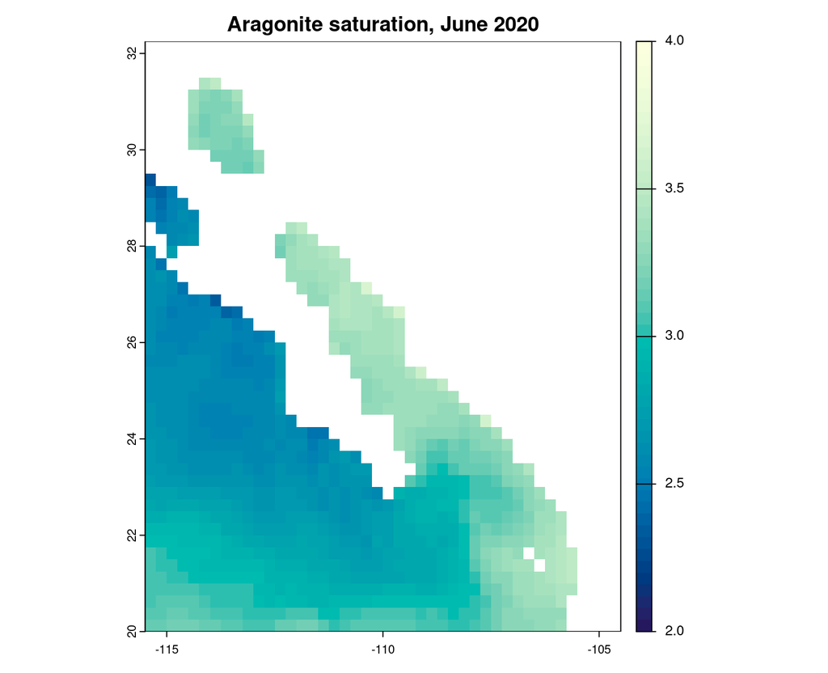

```r
# One summer month, so the map is a saturation state and not yet a pressure.
june_2020 <- monthly[[format(time(monthly), "%Y-%m") == "2020-06"]]
plot(june_2020, main = "Aragonite saturation, June 2020", range = c(2, 4), col = hcl.colors(50, "YlGnBu"))
```

## 2. Annual means

Each year becomes the mean of its twelve months. These rasters are the raw values used later. They are written to `int/prs_oa` as `oa_annual_<year>.tif`.

```r
year_index <- as.integer(format(time(monthly), "%Y"))
annual <- tapp(monthly, year_index, fun = mean, na.rm = TRUE)
annual <- ifel(is.nan(annual), NA, annual)
names(annual) <- as.character(sort(unique(year_index)))

stopifnot(as.integer(names(annual)) == score_years)

for (yr in score_years) {
  writeRaster(
    annual[[as.character(yr)]],
    file.path(int_dir, sprintf("oa_annual_%s.tif", yr)),
    overwrite = TRUE
  )
}

summary(values(annual[["2025"]]))
```

```
##       2025
##  Min.   :2.298
##  1st Qu.:2.779
##  Median :3.005
##  Mean   :2.966
##  3rd Qu.:3.154
##  Max.   :3.394
##  NA's   :1216
```

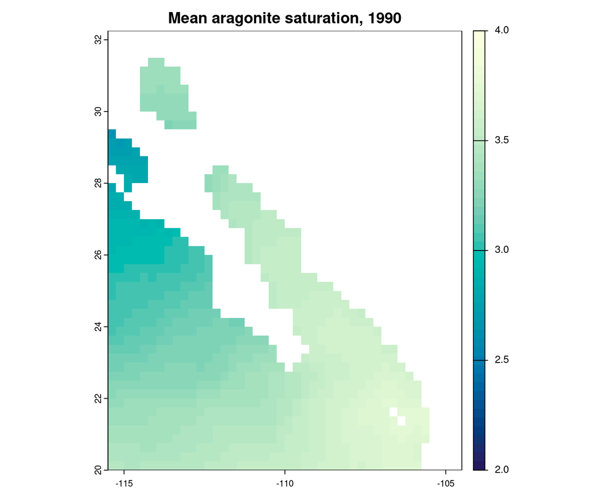

```r
plot(annual[["1990"]], main = "Mean aragonite saturation, 1990", range = c(2, 4), col = hcl.colors(50, "YlGnBu"))
```

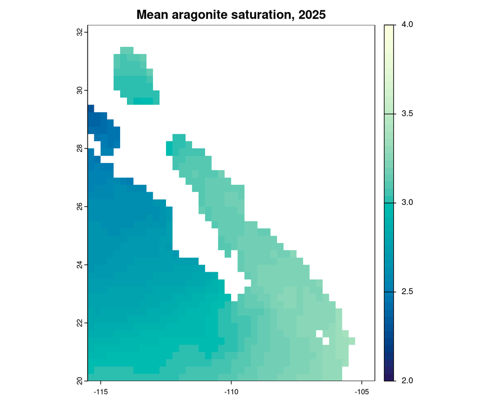

```r
plot(annual[["2025"]], main = "Mean aragonite saturation, 2025", range = c(2, 4), col = hcl.colors(50, "YlGnBu"))
```

## 3. Baseline, 1985–1994

The baseline is the mean of the ten annual rasters, cell by cell. A later decline is measured from this map, not from a single year.

```r
baseline <- mean(annual[[as.character(baseline_years)]], na.rm = TRUE)
baseline <- ifel(is.nan(baseline), NA, baseline)
names(baseline) <- "omega_baseline"

writeRaster(
  baseline,
  file.path(int_dir, "oa_baseline_1985_1994.tif"),
  overwrite = TRUE
)

# The denominator of the score is baseline − 1. It must stay positive.
stopifnot(minmax(baseline)[1, ] > 1)

data.frame(
  min = minmax(baseline)[1, ],
  max = minmax(baseline)[2, ]
)
```

```
##        min      max
## 1 2.613929 3.679237
```

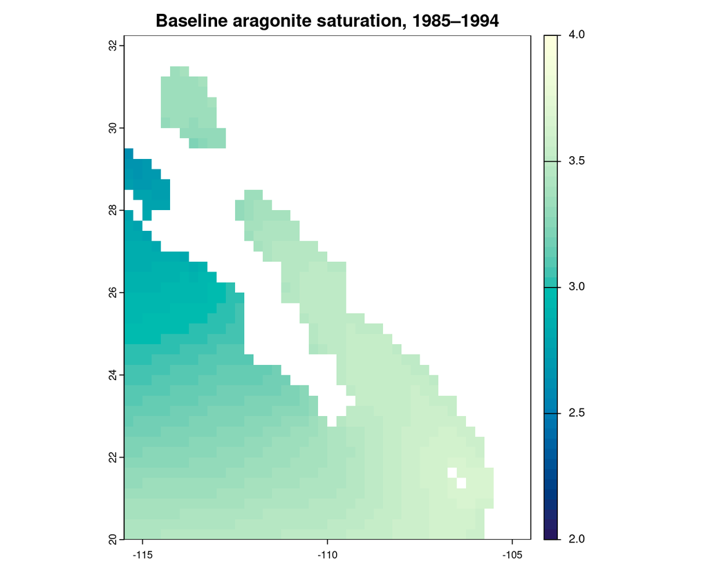

```r
plot(baseline, main = "Baseline aragonite saturation, 1985–1994", range = c(2, 4), col = hcl.colors(50, "YlGnBu"))
```

## 4. Rescale to a pressure

```r
# Share of the gap from the baseline down to 1 that has been lost.
delta <- (baseline - annual) / (baseline - 1)

pressure <- ifel(annual <= 1, 1, delta)
pressure <- ifel(pressure < 0, 0, pressure)
pressure <- ifel(pressure > 1, 1, pressure)
pressure <- mask(pressure, annual)
names(pressure) <- names(annual)

for (yr in score_years) {
  writeRaster(
    pressure[[as.character(yr)]],
    file.path(int_dir, sprintf("oa_rescaled_%s.tif", yr)),
    overwrite = TRUE
  )
}

summary(values(pressure[["2025"]]))
```

```
##       2025
##  Min.   :0.0919
##  1st Qu.:0.1385
##  Median :0.1617
##  Mean   :0.1565
##  3rd Qu.:0.1745
##  Max.   :0.1956
##  NA's   :1225
```

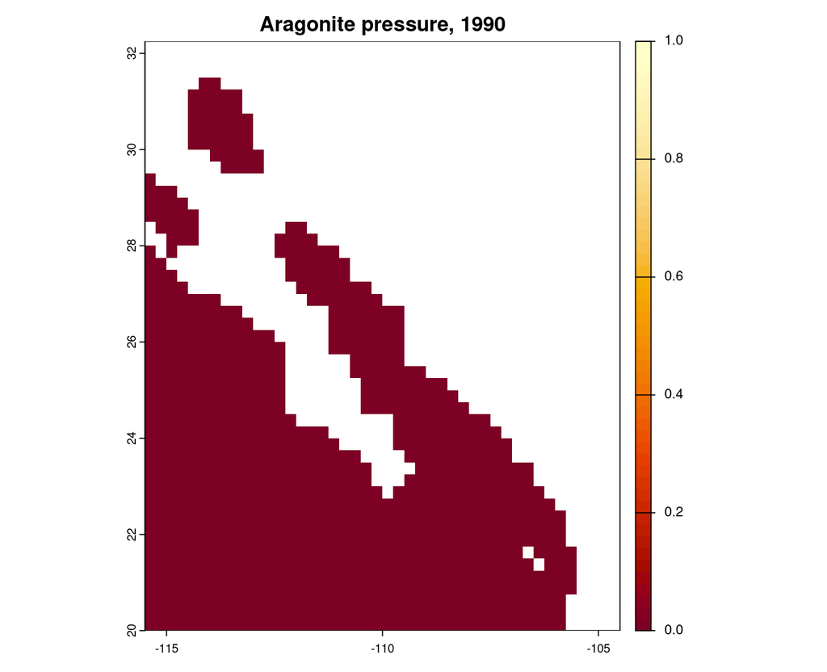

```r
plot(pressure[["1990"]], main = "Aragonite pressure, 1990", range = c(0, 1), col = hcl.colors(50, "YlOrRd"))
```

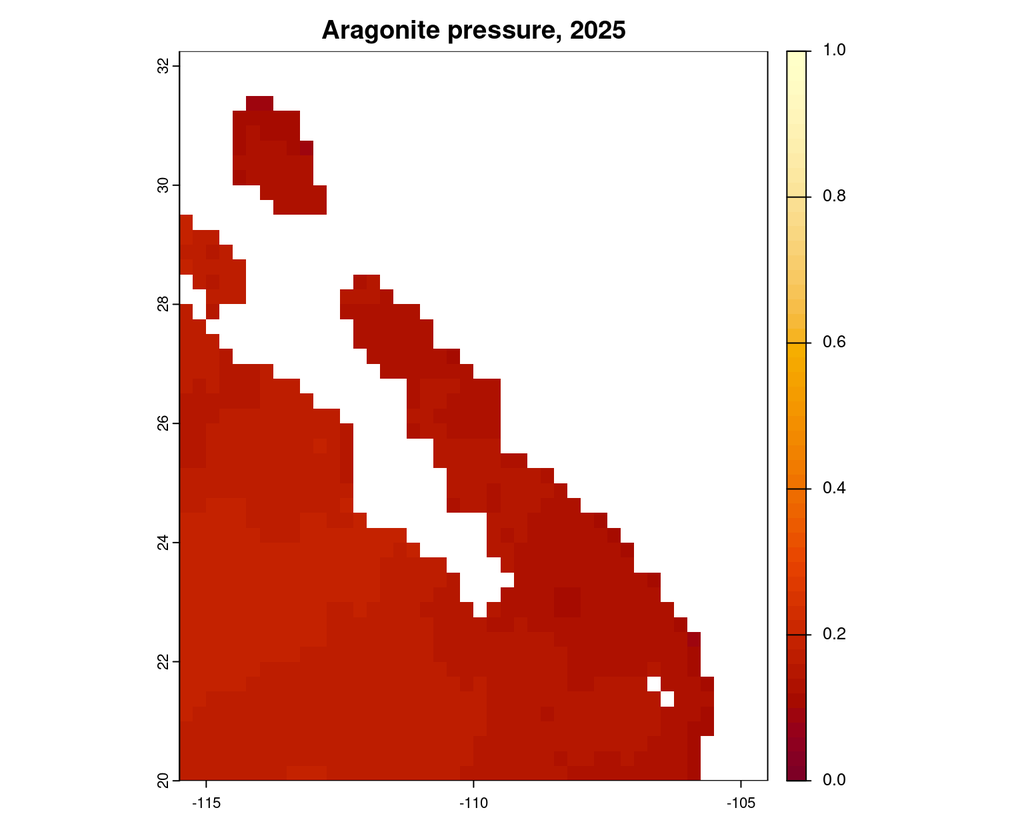

```r
plot(pressure[["2025"]], main = "Aragonite pressure, 2025", range = c(0, 1), col = hcl.colors(50, "YlOrRd"))
```

## 5. Mean pressure in each marine region

Each 0.25° cell is weighted by how much of it sits inside the region. These are the annual pressures, before any smoothing.

```r
marine <- st_read(rgn_path, quiet = TRUE) %>%
  filter(location == "marine") %>%
  st_transform(4326) %>%
  arrange(rgn_id)

annual_scores <- lapply(score_years, function(yr) {
  layer <- pressure[[as.character(yr)]]
  tibble(
    rgn_id = marine$rgn_id,
    year = yr,
    pressure = exact_extract(layer, marine, "mean")
  )
}) %>%
  bind_rows() %>%
  arrange(rgn_id, year)
```

[output not shown]

[output cut: 23 more lines]

```r
# How large is a typical year-to-year jump, compared with the rise since the baseline decade?
year_steps <- annual_scores %>%
  group_by(rgn_id) %>%
  arrange(year) %>%
  mutate(step = abs(pressure - lag(pressure))) %>%
  ungroup()

mean_step <- mean(year_steps$step, na.rm = TRUE)
max_step <- max(year_steps$step, na.rm = TRUE)
rise_to_2025 <- annual_scores %>%
  filter(year == 2025) %>%
  summarise(rise = mean(pressure)) %>%
  pull(rise)
```

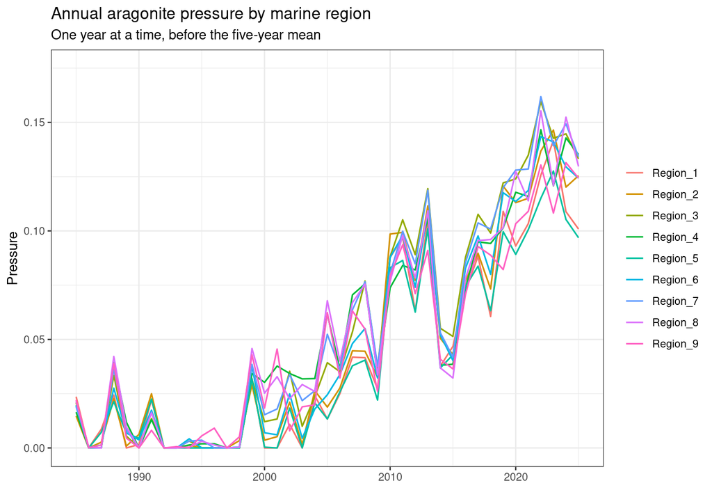

```r
ymax <- max(annual_scores$pressure, na.rm = TRUE) * 1.08

ggplot(annual_scores, aes(year, pressure, color = rgn_id)) +
  geom_line(linewidth = 0.6) +
  scale_y_continuous(limits = c(0, ymax)) +
  labs(
    title = "Annual aragonite pressure by marine region",
    subtitle = "One year at a time, before the five-year mean",
    x = NULL,
    y = "Pressure",
    color = NULL
  ) +
  theme_bw()
```

The lines rise, and they also jump. The average step from one year to the next is 0.017. The largest step is 0.072. The mean pressure in 2025, still unsmoothed, is only 0.123. One odd year can therefore erase or double the change that accumulated over the whole record. Those jumps come from upwelling, El Niño, and noise in the reconstruction. They are not the persistent acidification signal.

The saved pressure is the mean of the current year and the four years before it. For 2025 that is the mean of 2021–2025. The first year with five years of history is 1989, so the table starts there. A real shift then shows up over a couple of years rather than all at once.

```r
# lag() stays inside the region, so each window is that region's own previous years.
pressure_csv <- annual_scores %>%
  group_by(rgn_id) %>%
  mutate(
    pressure = (
      pressure +
        lag(pressure, 1) +
        lag(pressure, 2) +
        lag(pressure, 3) +
        lag(pressure, 4)
    ) / 5
  ) %>%
  ungroup() %>%
  filter(!is.na(pressure)) %>%
  arrange(year, rgn_id)

csv_path <- file.path(out_dir, "oa_pressure.csv")
write_csv(pressure_csv, csv_path)

kable(
  pressure_csv %>% filter(year %in% c(1990, 2010, 2025)),
  digits = 3,
  caption = "Five-year mean regional pressure"
)
```

Five-year mean regional pressure

| rgn_id | year | pressure |
| --- | --- | --- |
| Region_1 | 1990 | 0.007 |
| Region_2 | 1990 | 0.006 |
| Region_3 | 1990 | 0.008 |
| Region_4 | 1990 | 0.010 |
| Region_5 | 1990 | 0.008 |
| Region_6 | 1990 | 0.008 |
| Region_7 | 1990 | 0.009 |
| Region_8 | 1990 | 0.010 |
| Region_9 | 1990 | 0.009 |
| Region_1 | 2010 | 0.045 |
| Region_2 | 2010 | 0.050 |
| Region_3 | 2010 | 0.058 |
| Region_4 | 2010 | 0.058 |
| Region_5 | 2010 | 0.042 |
| Region_6 | 2010 | 0.051 |
| Region_7 | 2010 | 0.059 |
| Region_8 | 2010 | 0.059 |
| Region_9 | 2010 | 0.051 |
| Region_1 | 2025 | 0.116 |
| Region_2 | 2025 | 0.129 |
| Region_3 | 2025 | 0.143 |
| Region_4 | 2025 | 0.132 |
| Region_5 | 2025 | 0.109 |
| Region_6 | 2025 | 0.131 |
| Region_7 | 2025 | 0.143 |
| Region_8 | 2025 | 0.134 |
| Region_9 | 2025 | 0.121 |

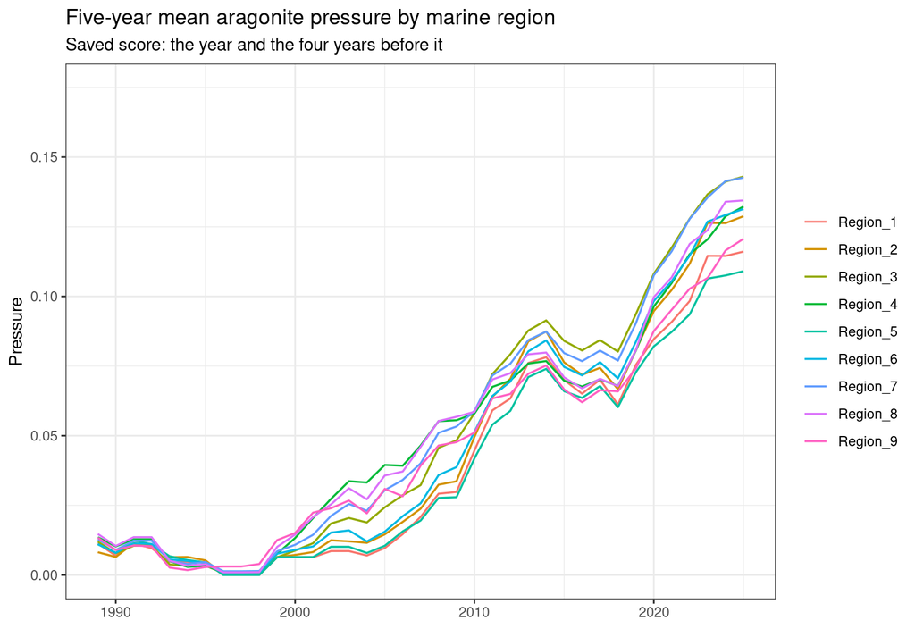

```r
ggplot(pressure_csv, aes(year, pressure, color = rgn_id)) +
  geom_line(linewidth = 0.6) +
  scale_y_continuous(limits = c(0, ymax)) +
  labs(
    title = "Five-year mean aragonite pressure by marine region",
    subtitle = "Saved score: the year and the four years before it",
    x = NULL,
    y = "Pressure",
    color = NULL
  ) +
  theme_bw()
```

The table is /home/frazier/ohi_goc_prep/_pressures/prs_oa/output/oa_pressure.csv.